# PBC analysis using clustGLMM

Jan Vávra

2026-02-25

The goal of this vignette is to replicate the analysis of PBC data performed by (Vávra et al. 2024) with the use of `clustGLMM` package. This is the list of packages required for the analysis:

```r
library(survival)
library(mixAK)
library(clustGLMM)
```

## PBC910

The sequential PBC data can be found in `pbcseq` from library `survival`. We restrict ourselves only to patients who survived the first 910 days (2.5 years) similarly as (Komárek and Komárková 2014), who created `PBC910` data in library `mixAK`. However, we need more columns than `PBC910` provides so we create our `data` from `pbcseq` by taking the same rows as `PBC910`.

```r
data(PBC910, package = "mixAK")
data(pbcseq, package = "survival")
data <- merge(PBC910, pbcseq, by = c("id", "day", "platelet", "spiders"))
dim(data)
```

```
#> [1] 918  24
```

```r
(n <- length(unique(data$id)))      # number of subjects in the data
```

```
#> [1] 260
```

Next we prepare the outcomes for analysis:

```r
data$ord_edema <- factor(data$edema, ordered = TRUE)
data$lalbumin <- log(data$albumin)
data$time <- data$day/365.24
```

The analysis in the paper consisted of

- numeric serum bilirubin and albumin (both on log-scales),
- binary indicators of blood vessel malformations in the skin (`spiders`) and presence of hepatomegaly or enlarged liver (`hepato`),
- ordinal `edema` (0 = no edema, 0.5 = untreated or succesfully treated, 1 = edema despite diuretic therapy).

We create `family` argument to declare the type of the considered outcomes for `clustGLMM` analysis:

```r
family <- c(lbili = "num", platelet = "poi", spiders = "bin")
```

The formulas for analysis will be the same for all outcomes. The fixed effects part will be an additive model with linear effect of `time` and `age` adjusted for different `sex`. All these effects are assumed to be group-specific. Finally, outcomes are joined via random intercepts.

```r
formula <- list()
for (y in names(family)) {
  formula[[y]] <- list()
  formula[[y]]$fixed <- ~ 1 # will become ~ 0
  formula[[y]]$group <- ~ time + age + sex
  formula[[y]]$random <- ~ 1
}
```

Below we show the summary of the variables considered within this analysis:

```r
summary(data[, c("time", "age", "sex", names(family))])
```

```
#>       time            age       sex         lbili           platelet      spiders
#>  Min.   :0.000   Min.   :26.3   m: 97   Min.   :-2.303   Min.   : 46   Min.   :0.000
#>  1st Qu.:0.000   1st Qu.:41.4   f:821   1st Qu.:-0.357   1st Qu.:190   1st Qu.:0.000
#>  Median :0.587   Median :48.8           Median : 0.182   Median :249   Median :0.000
#>  Mean   :0.842   Mean   :49.0           Mean   : 0.387   Mean   :255   Mean   :0.269
#>  3rd Qu.:1.161   3rd Qu.:56.1           3rd Qu.: 0.993   3rd Qu.:311   3rd Qu.:1.000
#>  Max.   :2.481   Max.   :78.4           Max.   : 3.466   Max.   :713   Max.   :1.000
#>                                                          NA's   :15    NA's   :5
```

We see that some of the binary outcome values are missing. However, for `clustGLMM` there is no need for omitting the rows from the analysis as long as the missing values are among modelled outcomes.

Now we examine how does the outcome evolve in time:

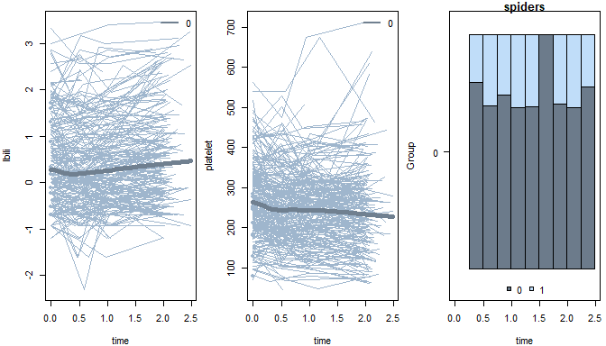

```r
par(mfrow = c(1,3))
par(mar = c(4,4,1,0.5))
plot_num_vs_x_grouped(data, y = "lbili", x = "time", id = "id")
plot_num_vs_x_grouped(data, y = "platelet", x = "time", id = "id")
plot_cat_vs_x_grouped(data, y = "spiders", x = "time", main = "spiders")
```

## Sampling MCMC using `clustGLMM`

Some of the key inputs for `clustGLMM` are already prepared (`family`, `formula`), but there still some key settings to be discussed. Non-effects parameters of the model may also be set to be group-specific. The default setting is provided by

```r
(varying <- default_varying())
```

```
#> prec_num    c_ord InvSigma     InvQ      naY
#>     TRUE     TRUE    FALSE    FALSE    FALSE
```

Only precision of the errors of numeric outcomes and ordered intercepts are considered to be group-specific parameters by default. We set the precision matrix (`InvSigma`) of the vector of random intercepts to be group-specific as well, but keep its Wishart prior scale matrix `InvQ` common to all groups. Missing outcome values will be always predicted for the current cluster the individual is assigned to.

```r
varying["prec_num"] <- TRUE
varying["InvSigma"] <- TRUE
```

Next, we can choose which parameters are returned. We make just one change compared to the default setting and that is to save the predicted missing values.

```r
save <- default_save()
save["naY"] <- TRUE
```

```r
tuning <- default_tuning(experience = TRUE)
param <- default_param(sparse = TRUE)
# data$platelet <- round(data$platelet / 100)
```

```r
set.seed(123456789)
mcmc_burnin <- clustGLMM(formula = formula, id = "id", family = family, data = data,
                         G = 10, nchains = 2, iter = 1000,
                         varying = varying, save = save, tuning = tuning, param = param,
                         standardize = TRUE)
```

[output not shown]

The default `plot` output informs us about the evolution of number of patients within each cluster separately for all chains:

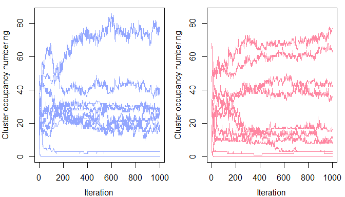

```r
plot(mcmc_burnin)
```

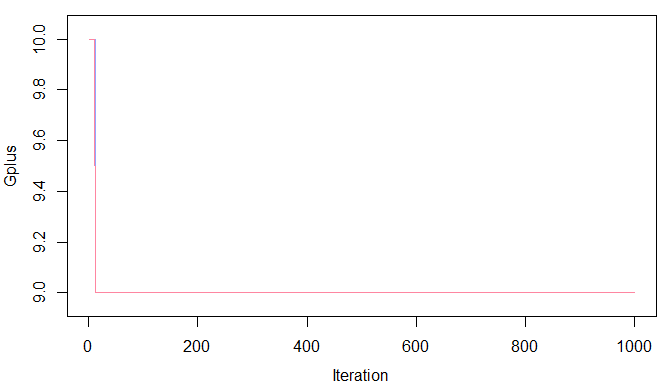

```r
plot(mcmc_burnin, "Gplus")
```

The current chains cannot be used for inference. We continue to sample from initial values set to `mcmc_burnin$last`:

```r
mcmc_burnin <- clustGLMM(formula = formula, id = "id", family = family, data = data,
                         G = 10, nchains = 2, iter = 1000,
                         inits = mcmc_burnin$last,
                         varying = varying, save = save, tuning = tuning, param = param,
                         standardize = TRUE)
```

[output not shown]

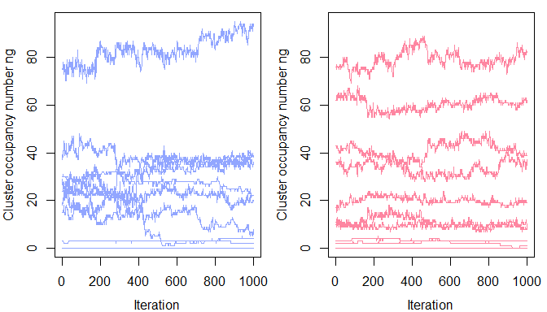

```r
plot(mcmc_burnin)
```

Now we sample next $10\,000$ iterations.

```r
mcmc <- clustGLMM(formula = formula, id = "id", family = family, data = data,
                  G = 10, nchains = 2, iter = 10000,
                  inits = mcmc_burnin$last,
                  varying = varying, save = save, tuning = tuning, param = param,
                  standardize = TRUE)
```

[output not shown]

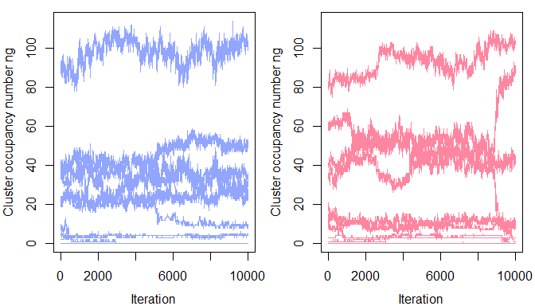

```r
plot(mcmc)
```

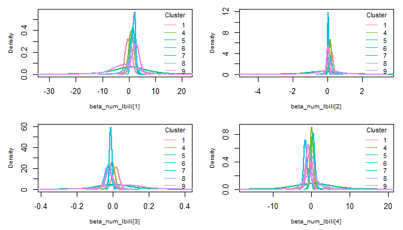

```r
ch <- 1
plot(mcmc, "beta_num", "clusters_kerneldensity", chain = ch)
```

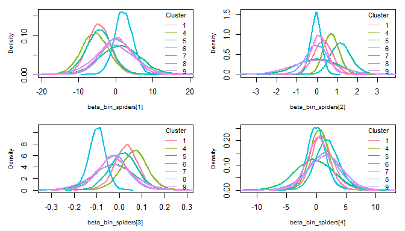

```r
plot(mcmc, "beta_bin", "clusters_kerneldensity", chain = ch)
```

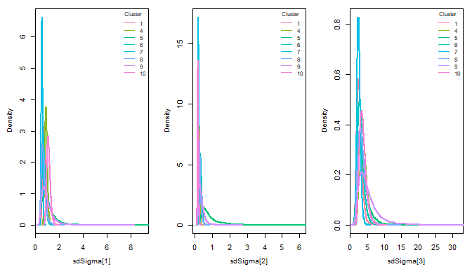

```r
plot(mcmc, "beta_ord", "clusters_kerneldensity", chain = ch)
plot(mcmc, "c_ord", "clusters_kerneldensity", chain = ch)
plot(mcmc, "sdSigma", "clusters_kerneldensity", chain = ch)
```

[output not shown]

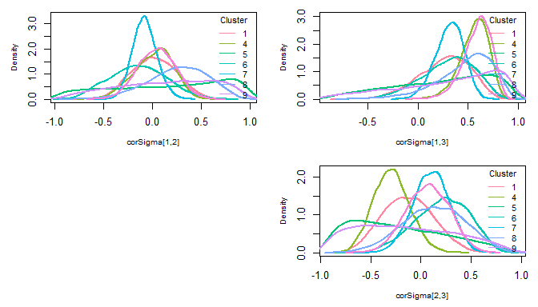

```r
plot(mcmc, "corSigma", "clusters_kerneldensity", chain = ch)
```

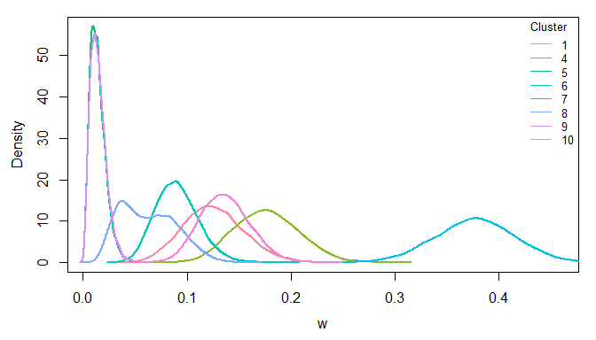

```r
plot(mcmc, "w", "clusters_kerneldensity", chain = ch)
```

```r
mcmc_pp <- post_processing(mcmc)
```

```r
data[,paste0("Uclustering", ch)] <- mcmc_pp$clustering[as.character(data$id),ch]
```

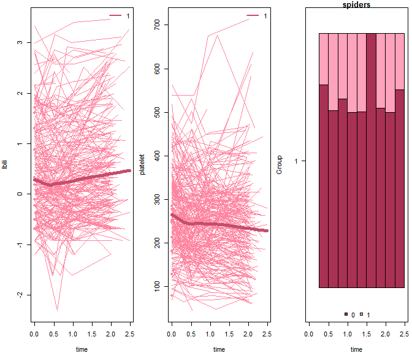

```r
par(mfrow = c(1,3))
par(mar = c(4,4,1,0.5))
plot_num_vs_x_grouped(data, y = "lbili", x = "time", group = "Uclustering1", id = "id")
plot_num_vs_x_grouped(data, y = "platelet", x = "time", group = "Uclustering1", id = "id")
plot_cat_vs_x_grouped(data, y = "spiders", x = "time", group = "Uclustering1", main = "spiders")
```